# 2 Data Visualization

Hikaru Hashimoto

2023-05-09

## 2.4 Visualizing Distributions

Categorical variable (qualitative variable):カテゴリ変数（質的変数）  
(例)  
-血液型  
-コインの表裏

質的変数を数字に変換（エンコーディング）する必要がときどきある。機械学習のデータとして使うときなど量的変数をそのまま学習データとして使えない場合には以下のような方法でコンピュータで処理できる情報に置き換える。

1. ordinal encoding  
   たとえば血液型ならA型を1、B型を2、O型を3、AB型を4に置き換える。
2. one-hot encoding  
   [参考](https://datatricks.co.uk/one-hot-encoding-in-r-three-simple-methods)。

他にもハッシュエンコーディングやターゲットエンコーディングなどがある（[参考](https://www.renom.jp/ja/notebooks/tutorial/preprocessing/category_encoding/notebook.html)）。

Numerical variable (quantitative variable):数的変数（量的変数）  
-身長（連続値）  
-テストの点数（離散値）

### 2.4.1 A Categorical Variable

### 2.4.2 A numerical Variable

普通に考えたらbody_mass_gは正規分布するはずだから形が変。  
→Speciesぜんぶ入っている。

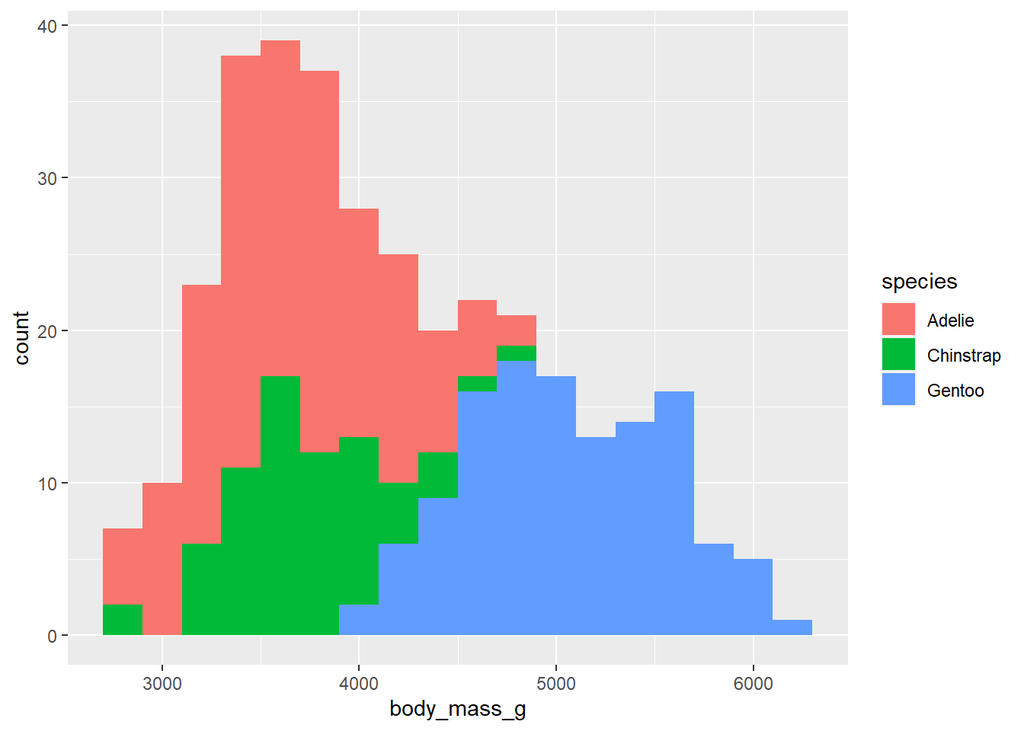

```r
ggplot(penguins, aes(x = body_mass_g, fill = species)) +
  geom_histogram(binwidth = 200)
```

### 2.4.3 Exercises

#### 1. A Bar Plot of Species of Penguins

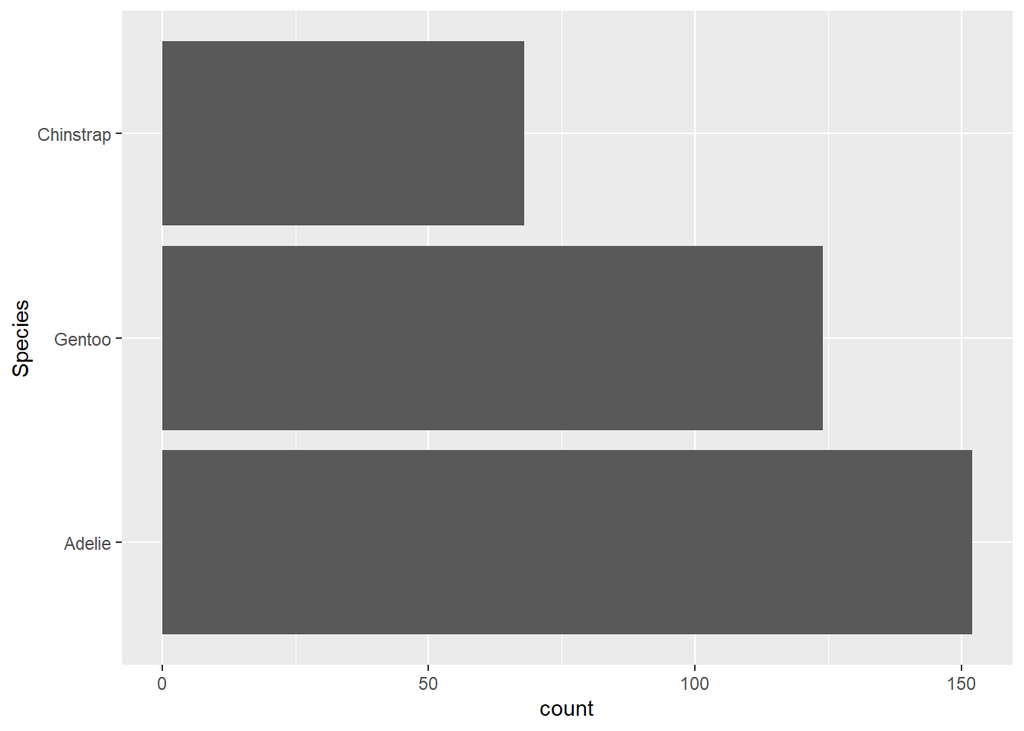

```r
ggplot(penguins, aes(y = fct_infreq(species))) +
  geom_bar() +
  labs(y = "Species")
```

#### 2. Difference of the Two Plots

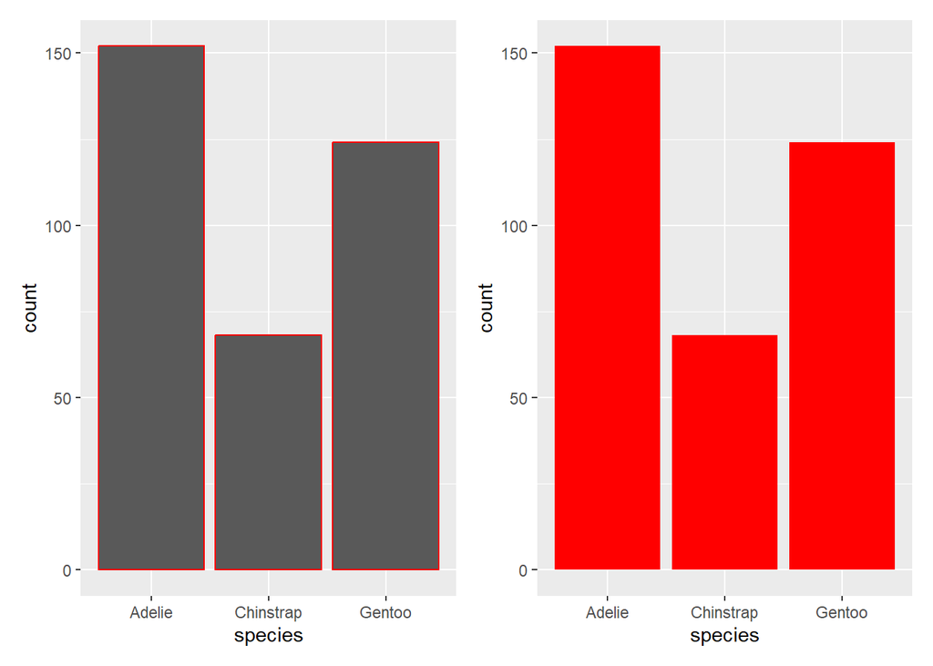

```r
p1 <- ggplot(penguins, aes(x = species)) +
  geom_bar(color = "red")

p2 <- ggplot(penguins, aes(x = species)) +
  geom_bar(fill = "red")

p1 + p2
```

この出力(p1 + p2)はpatchworkというライブラリを使っています。簡単にplotを組み合わせられるイカしたやつです。

#### 3. bins argument in geom_histogram()

Number of bins. Overridden by binwidth. Defaults to 30.
ビンの数の参考になるものとしてスタージェスの公式がある。
$$ビンの数 = 1 + log_2N$$

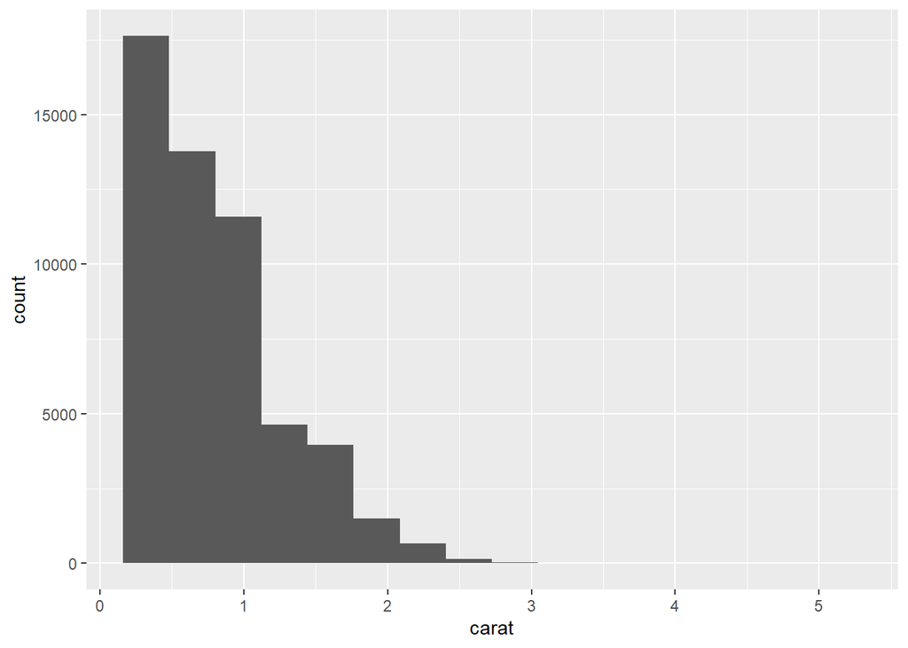

```r
num_bin = 1 + trunc(log2(nrow(diamonds)))

ggplot(diamonds, aes(x = carat)) +
  geom_histogram(bins = num_bin)
```

#### 4. histogram of carat

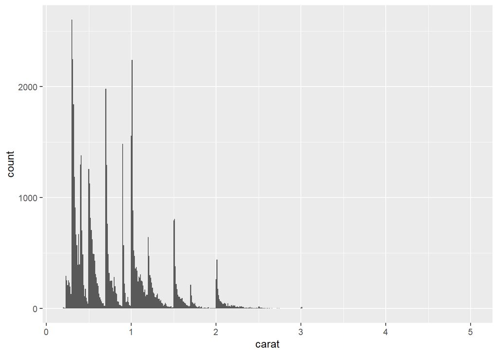

```r
ggplot(diamonds, aes(x = carat)) +
  geom_histogram(binwidth = 0.01)
```

binwidth = 0.01 reveals an interesting pattern. Carats are not normally distributed (kinda understandable), and there are several peaks around 0.25, 0.5, and so on. It may be because diamonds are cut aiming at the carats.

## 2.5 Visualizing Relationships

### 2.5.1 A numerical and a Categorical Variable

用語：  
25th percentile:第一四分位数  
50th percentile:第二四分位数（中央値）  
75th percentile:第三四分位数  
interquartile range: 四分位範囲

density:密度

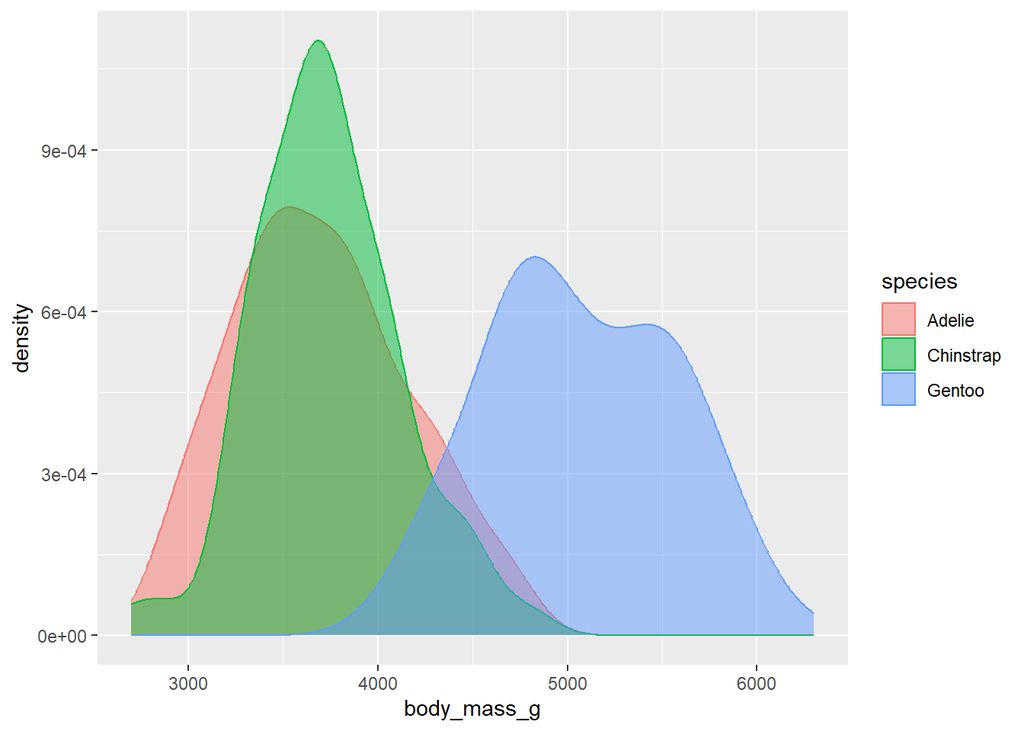

```r
kernel_plot <- ggplot(penguins, aes(x = body_mass_g, color = species, fill = species)) +
  geom_density(alpha = 0.5)

kernel_plot
```

geom_densityは[カーネル密度推定](https://analytics-note.xyz/statistics/kernel-density-estimation/)を行っている。何をやっているのか正直あまりピンと来ていないが、どうやら持っているデータから母集団の分布をノンパラメトリックな手法で推定している。

素朴な疑問として、ここで扱っている体重はSpeciesごとなら正規分布していそうなので、パラメータ(母平均と母分散)を推定すればよいのでは？とくにplotしたいのであればspeciesごとに母平均と母分散を点推定して、その数値をもとに正規分布をspeciesごとに重ねていった方が母集団を近似するのでは？

母集団が正規分布しているときの点推定は標本平均と不偏分散を使えばいいので、それぞれのSpeciesの母分散を推定して図示してみる。

```r
Adelie <- penguins %>%
  filter(species == "Adelie")

Gentoo <- penguins %>%
  filter(species == "Gentoo")

Chinstrap <- penguins %>%
  filter(species == "Chinstrap")

# 標本平均はmean()の関数、不偏分散はvar()の関数で出せる。ただしna.rm = TRUEにしないとnaが入っているデータだとNAが返ってくる。
mean(Adelie$body_mass_g, na.rm = TRUE)
```

```
## [1] 3700.662
```

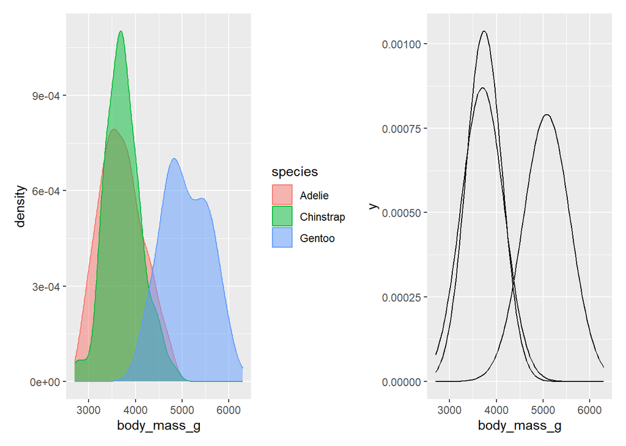

```r
dist_norm <- ggplot(data=penguins, aes(x = body_mass_g)) +
  stat_function(
    fun = dnorm,
    args= list(mean = mean(Adelie$body_mass_g, na.rm = TRUE),
               sd = sqrt(var(Adelie$body_mass_g, na.rm = TRUE)))
  ) +
  stat_function(
    fun = dnorm,
    args= list(mean = mean(Gentoo$body_mass_g, na.rm = TRUE),
               sd = sqrt(var(Gentoo$body_mass_g, na.rm = TRUE)))
  ) +
  stat_function(
    fun = dnorm,
    args= list(mean = mean(Chinstrap$body_mass_g, na.rm = TRUE),
               sd = sqrt(var(Chinstrap$body_mass_g, na.rm = TRUE)))
  )

kernel_plot + dist_norm
```

### 2.5.2 Two Categorical Varibales

とくに面白かったものなし

### 2.5.3 Two numerical Variables

とくに面白かったものなし

### 2.5.4 Three or More Variables

テキストとちょっと変えて、島ごとにではなく種類ごとに分けてプロットしてみる。ChinstrapとGentooは一つの島にしかいないので面白くない。Adelieについては島ごとに違いがあまりなさそうというのがはっきりわかる。

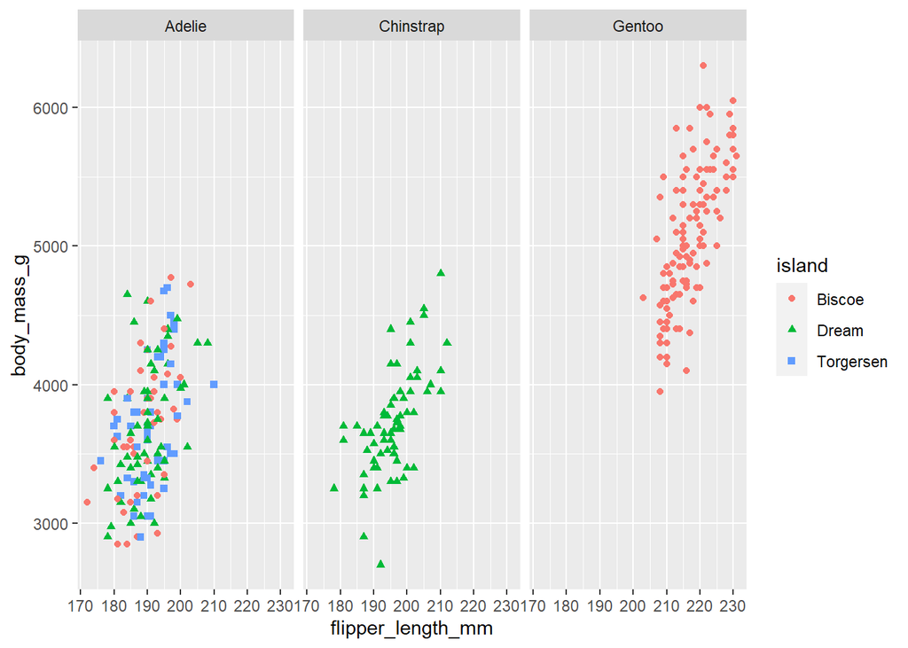

```r
ggplot(penguins, aes(x = flipper_length_mm, y = body_mass_g)) +
  geom_point(aes(color = island, shape = island)) +
  facet_wrap(~species)
```

### 2.5.5 Exercises

#### 1. mpg data

apply系関数を使ってみました。[参考](http://takenaka-akio.org/doc/r_auto/chapter_07_apply.html) lapplyだと戻り値がリストになるので何もしなくてもある程度見れる表示で返ってきた。

```r
lapply(mpg, class)
```

```
## $manufacturer
## [1] "character"
##
## $model
## [1] "character"
##
## $displ
## [1] "numeric"
##
## $year
## [1] "integer"
##
## $cyl
## [1] "integer"
##
## $trans
## [1] "character"
##
## $drv
## [1] "character"
##
## $cty
## [1] "integer"
##
## $hwy
## [1] "integer"
##
## $fl
## [1] "character"
##
## $class
## [1] "character"
```

#### 2 scatterplot of hwy vs. displ

hwy: highway miles per gallon displ: engine displacement(排気量), in litres year: year of manufacture cyl: number of cylinders

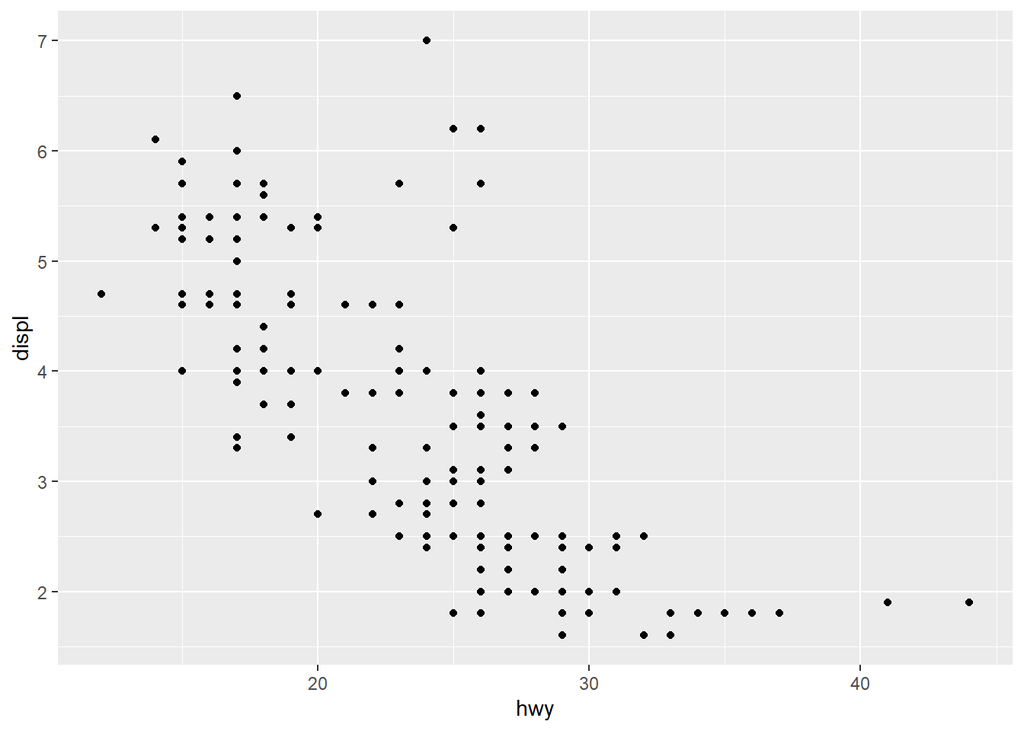

```r
base_scatter <- ggplot(mpg, aes(x = hwy, y = displ)) +
  geom_point()

plot(base_scatter)
```

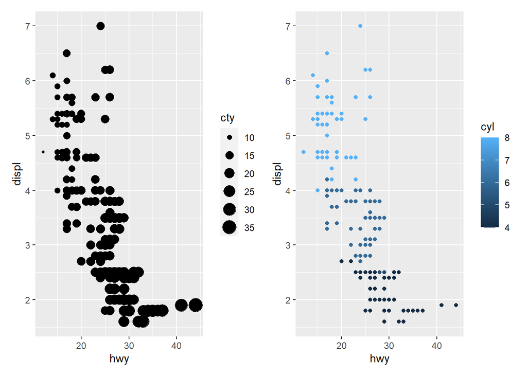

```r
scatt_color <- ggplot(mpg, aes(x = hwy, y = displ, color = cyl)) +
  geom_point()

scatt_size <- ggplot(mpg, aes(x = hwy, y = displ, size = cty)) +
  geom_point()

plot(scatt_size + scatt_color)
```

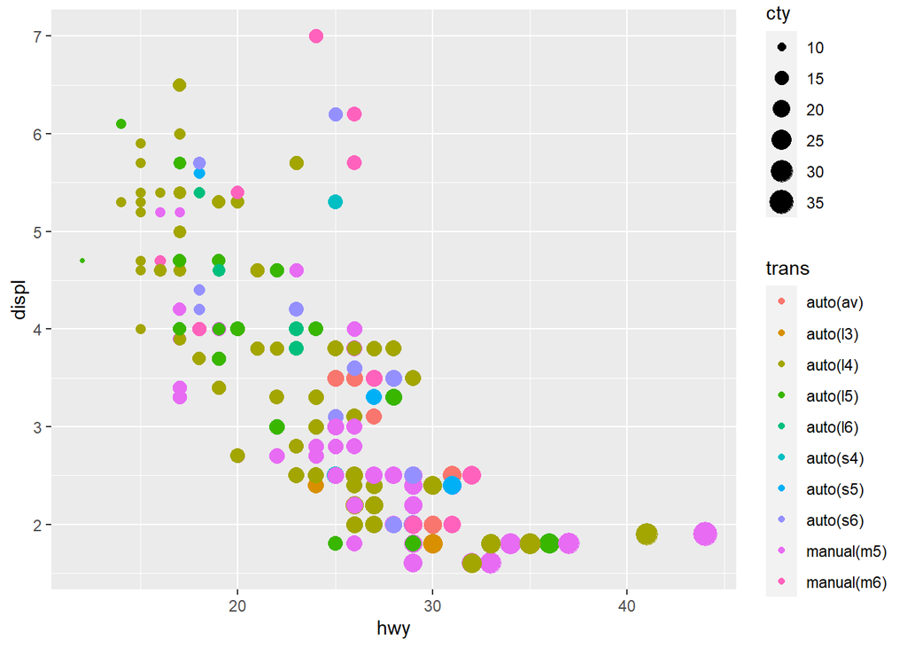

```r
scatt_size_color <- ggplot(mpg, aes(x = hwy, y = displ, color = trans, size = cty)) +
  geom_point()


plot(scatt_size_color)
```

#### 3 linewidth

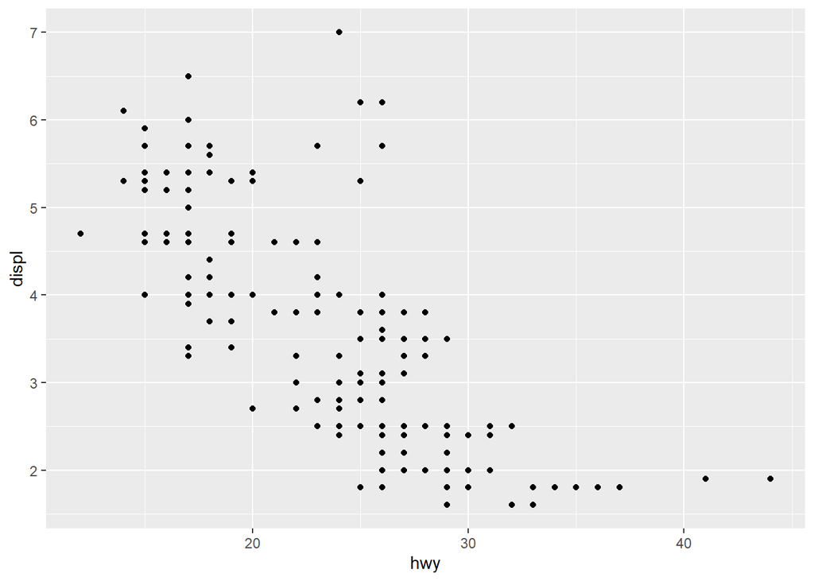

```r
width_scatter <- ggplot(mpg, aes(x = hwy, y = displ, linewidth = cty)) +
  geom_point()

plot(width_scatter)
```

#### 4 multiple aesthetics

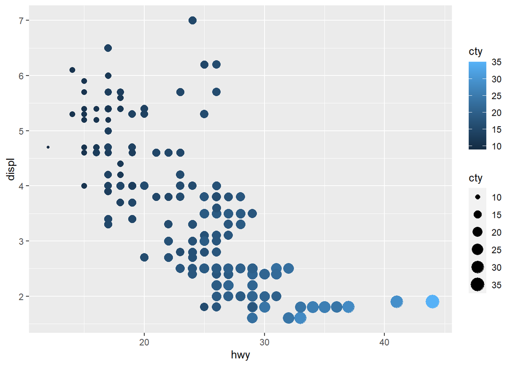

```r
width_scatter <- ggplot(mpg, aes(x = hwy, y = displ, color = cty, size = cty)) +
  geom_point()

plot(width_scatter)
```

#### 5 bill_depth_mm vs bill_length_mm

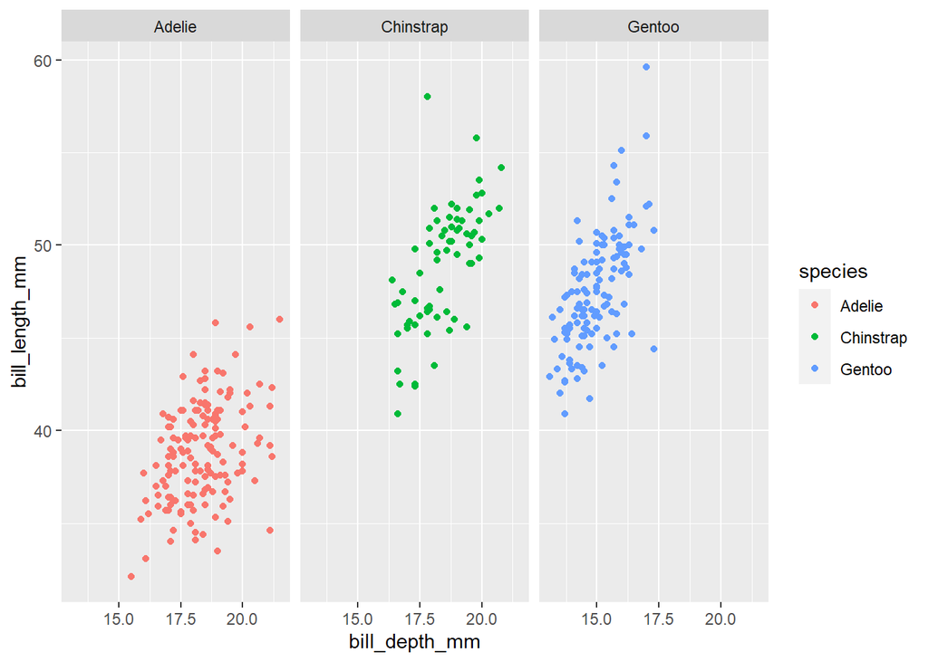

```r
ggplot(penguins, aes(x = bill_depth_mm, y = bill_length_mm, color = species)) +
  geom_point() +
  facet_wrap(~species)
```

#### 6 two separate legends

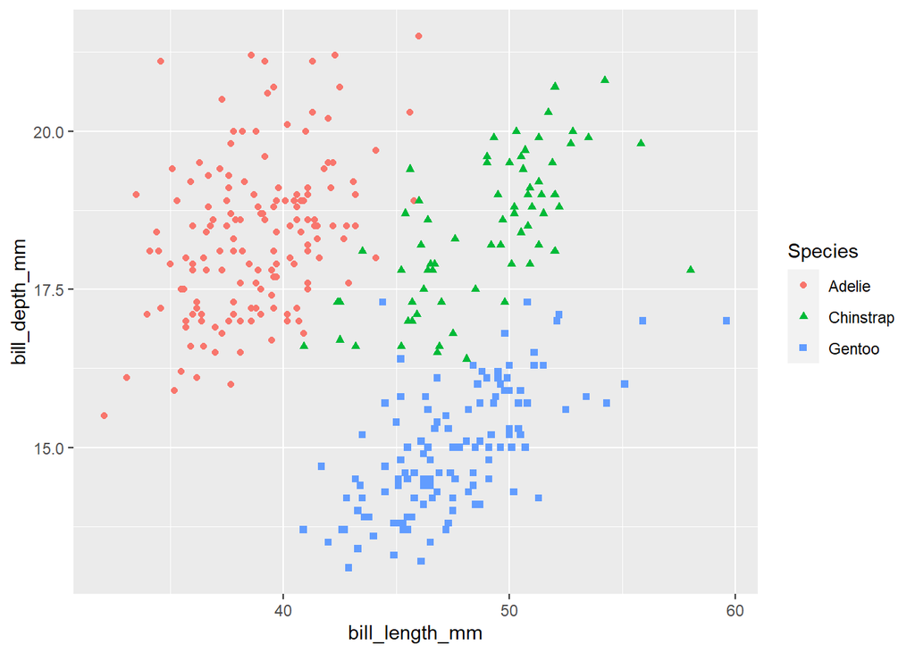

```r
ggplot(
  data = penguins,
  mapping = aes(
    x = bill_length_mm, y = bill_depth_mm,
    color = species, shape = species
  )
) +
  geom_point() +
  labs(color = "Species", shape = "Species") #ラベルの名前を揃える
```